# STAT/MATH 495: Problem Set 03

Leonard Yoon

2017-09-26

# Question

For both `data1` and `data2` tibbles (a tibble is a data frame with some [metadata](https://blog.rstudio.com/2016/03/24/tibble-1-0-0#tibbles-vs-data-frames) attached):

- Find the splines model with the best out-of-sample predictive ability.
- Create a visualization arguing why you chose this particular model.
- Create a visualization of this model plotted over the given $(x_i, y_i)$ points for $i=1,\ldots,n=3000$.
- Give your estimate $\widehat{\sigma}$ of $\sigma$ where the noise component $\epsilon_i$ is distributed with mean 0 and standard deviation $\sigma$.

## Data 1

```r
set.seed(18)
RMSE.opt <- rep(0, times=5) # initialize vector of lowest RMSE's from 5 folds
df.opt <- rep(0, times=5) # initialize vector of df's corresponding to lowest RMSE's from 5 folds
```

### Fold 1

I split `data1` into k = 5 folds. In the first fold, I randomly create a disjoint training set and test (validation) set. The test set is a random sample of 600 data points (1/5 of the data points) from data1 and the rest of data1 becomes the training set. For the training set in this first fold, I fit a spline model. Then I use predict() to take the model and create $\hat{y}$ values for the test set. Next, I compute a score (root mean squared error) by comparing the $\hat{y}$ values for the test set with the actual y values.

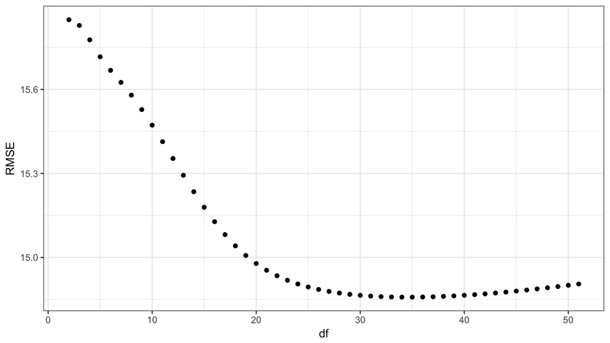

```r
# Create disjoint training and test data sets of size 2400 and 600, respectively
d1_samp_tr <- data1 %>% # data1_sample_train
  sample_n(2400)
d1_samp_te <- data1 %>% # data1_sample_test
  anti_join(d1_samp_tr, by="ID") # this is 1/5 of sample size of data1

dfs <- rep(2:51) # df = 2 through 51
RMSEs <- rep(0, times=50) # RMSE's for the given df's

for (i in 1:length(dfs)) {
  splines_model <- smooth.spline(x=d1_samp_tr$x, y=d1_samp_tr$y, df = dfs[i]) # fit spline model
  d1_samp_te$preds <- predict(splines_model,d1_samp_te$x)$y # y-hats created from predict()
  n <- length(d1_samp_te$preds) # n = 600
  MSE <- (1/n)*sum((d1_samp_te$y-d1_samp_te$preds)^2) # mean squared error
  RMSE <- sqrt(MSE) # root mean squared error
  RMSEs[i] <- RMSE # fill in the vector
}

# Visualization arguing for model
dataframe <- data.frame(dfs,RMSEs)
ggplot(dataframe, aes(x=dfs)) + geom_point(aes(y=RMSEs)) + theme_bw() + labs(x="df", y="RMSE")
```

```r
RMSE.opt[1] <- min(RMSEs) # choose minimum RMSE from model
df.opt[1] <- which.min(RMSEs) + 1 # choose corresponding df
# The position of the vector df.opt is actually 1 under the true df because the first position of the vector contains df = 2. That's why I have to add 1.
```

### Fold 2

For fold 2, I start by choosing as a test set 1/5 of the data set that has not yet been part of the test set in fold 1. Practically speaking, this means choosing 1800 points from the training set of fold 1 to remain as the training set for fold 2, and then adding the 600 points from the test set of fold 1 to also be part of the training set in fold 2. Then I fit a spline model to the new training set. Use predict() to take the model and create y-hat values for the test set. Compute score by comparing the y-hat values of the test set with the actual y values.

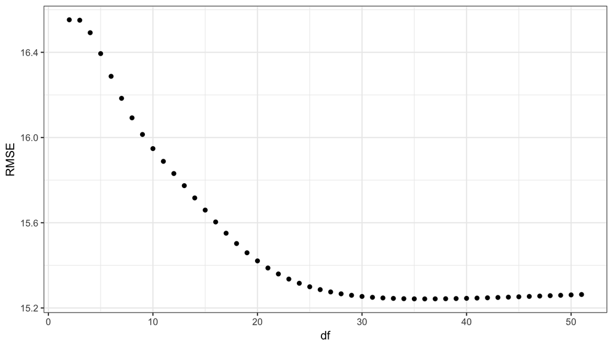

```r
# Repeat: sample 600 data points to be test set that are NOT in the previous test set
d1_samp_tr2 <- d1_samp_tr %>%
  sample_n(1800)
d1_samp_te2 <- d1_samp_tr %>%
  anti_join(d1_samp_tr2, by="ID")

# removes pred column so that I can use rbind
d1_samp_te <- d1_samp_te[-4]

# take the old test set and add it to the training set so that it's 2400 data points in the training set
d1_samp_tr2rb <- rbind(d1_samp_te,d1_samp_tr2)

dfs <- rep(2:51)
RMSEs <- rep(0, times=50) # RMSE's

for (i in 1:length(dfs)) {
  splines_model <- smooth.spline(x=d1_samp_tr2rb$x, y=d1_samp_tr2rb$y, df = dfs[i])
  d1_samp_te2$preds <- predict(splines_model,d1_samp_te2$x)$y
  n <- length(d1_samp_te2$preds)
  MSE <- (1/n)*sum((d1_samp_te2$y-d1_samp_te2$preds)^2)
  RMSE <- sqrt(MSE)
  RMSEs[i] <- RMSE
}

# Visualization arguing for model
dataframe <- data.frame(dfs,RMSEs)
ggplot(dataframe, aes(x=dfs)) + geom_point(aes(y=RMSEs)) + theme_bw() + labs(x="df", y="RMSE")
```

```r
RMSE.opt[2] <- min(RMSEs)
df.opt[2] <- which.min(RMSEs) + 1
```